# Home Healthcare Aides

Aaron Kessler

4/17/2020

The [Bureau of Labor Statistics](https://www.bls.gov/oes/tables.html) puts out extensive data on the workforce, including details down to the state and metro level. (The most recent localized data is from 2018, that’s what we’ll use here.)

We’ll use the occupation of “Home Health Aides” for this analysis. More information on the category can be found [here](https://www.bls.gov/ooh/healthcare/home-health-aides-and-personal-care-aides.htm).

Nationally, about 800,000 people work as such aides. They generally make little money despite the importance of their jobs in keeping people alive - averaging about $12/hr as of 2018.

## State and local level workforces

Now let’s analyze the BLS data more granularly to explore how different states compare with each other.

Since areas with the highest populations naturally tend to have more workers of any type, including those at restaurants and bars, we’ll account for that by using a rate of “jobs per 1,000 workers” so it’s more apples-to-apples. E.g. for each 1,000 workers in a state or metro area, how many are home health aides.

### States

Which states have the **lowest** share of their workforce per 1,000 workers as home health aides? (Shown below in the *jobs_1000* column).

| state | tot_emp | jobs_1000 |
| --- | --- | --- |
| New Hampshire | 550 | 0.835 |
| Nevada | 1,460 | 1.080 |
| North Dakota | 550 | 1.316 |
| Kentucky | 2,680 | 1.420 |
| California | 24,560 | 1.444 |
| Tennessee | 4,750 | 1.607 |
| Kansas | 2,320 | 1.684 |
| Vermont | 580 | 1.910 |
| South Dakota | 810 | 1.920 |
| Wisconsin | 5,600 | 1.964 |
| Wyoming | 630 | 2.329 |
| Rhode Island | 1,160 | 2.400 |
| Alabama | 4,870 | 2.504 |
| Virginia | 9,700 | 2.530 |
| Iowa | 3,940 | 2.552 |

Which states have the **highest** share of their workforce per 1,000 workers?

| state | tot_emp | jobs_1000 |
| --- | --- | --- |
| New York | 191,820 | 20.437 |
| Ohio | 55,490 | 10.245 |
| New Jersey | 41,040 | 10.134 |
| District of Columbia | 6,420 | 9.013 |
| Minnesota | 22,380 | 7.804 |
| Hawaii | 4,920 | 7.659 |
| Massachusetts | 25,220 | 7.061 |
| New Mexico | 5,680 | 7.002 |
| North Carolina | 30,040 | 6.854 |
| Pennsylvania | 36,940 | 6.317 |
| Arizona | 17,570 | 6.299 |
| Michigan | 26,580 | 6.156 |
| Texas | 69,600 | 5.745 |
| Illinois | 33,990 | 5.674 |
| South Carolina | 9,600 | 4.654 |

What’s the range in values we’re talking about states having by that measure:

| minvalue | maxvalue |
| --- | --- |
| 0.835 | 20.437 |

That’s a pretty large difference between the worst and the best.  
Let’s take a quick look at what the distribution looks like with a historgram.

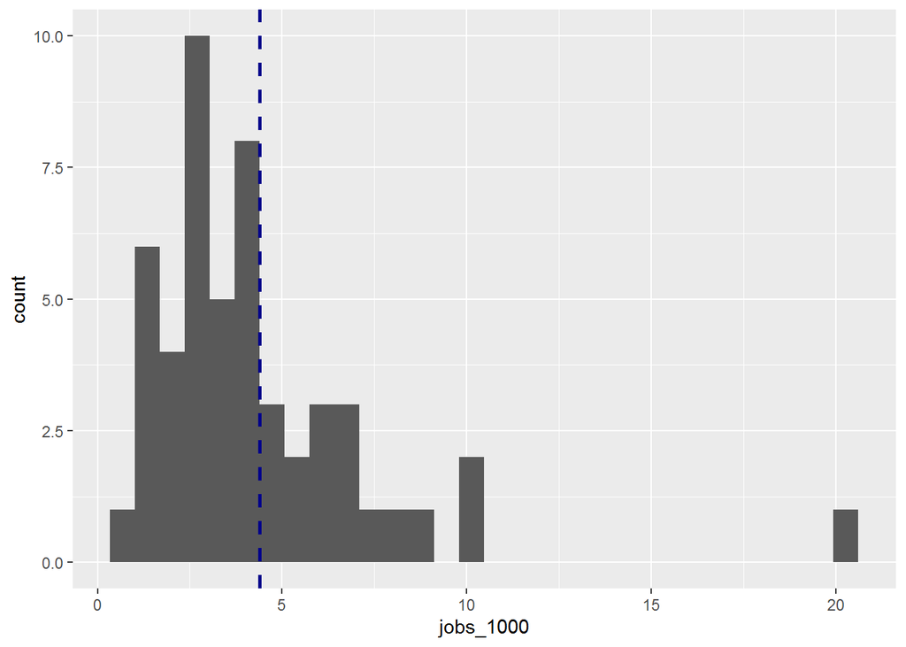

### Metro Areas

Now we’ll do the same thing but for **Metropolitan Statistical Areas (MSAs)**…

Which metro areas have the **lowest** share of their workforce per 1,000 workers as home health aides?

| area_name | tot_emp | jobs_1000 |
| --- | --- | --- |
| Bloomington, IL | 40 | 0.417 |
| Vallejo-Fairfield, CA | 80 | 0.591 |
| San Jose-Sunnyvale-Santa Clara, CA | 710 | 0.632 |
| Dubuque, IA | 40 | 0.679 |
| Elkhart-Goshen, IN | 100 | 0.736 |
| Warner Robins, GA | 50 | 0.755 |
| Odessa, TX | 60 | 0.832 |
| El Centro, CA | 50 | 0.843 |
| Iowa City, IA | 80 | 0.850 |
| Reno, NV | 200 | 0.853 |
| Santa Maria-Santa Barbara, CA | 170 | 0.912 |
| Oxnard-Thousand Oaks-Ventura, CA | 300 | 0.947 |
| Stockton-Lodi, CA | 240 | 0.968 |
| Salinas, CA | 180 | 0.976 |
| St. Joseph, MO-KS | 50 | 0.987 |

| area_name | tot_emp | jobs_1000 |
| --- | --- | --- |
| Brownsville-Harlingen, TX | 4,050 | 29.238 |
| Sherman-Denison, TX | 1,190 | 26.486 |
| McAllen-Edinburg-Mission, TX | 6,480 | 24.894 |
| New York-Newark-Jersey City, NY-NJ-PA | 202,660 | 21.336 |
| Bay City, MI | 570 | 17.034 |
| Flint, MI | 2,280 | 16.576 |
| Goldsboro, NC | 670 | 16.178 |
| Greenville, NC | 1,090 | 14.190 |
| Midland, MI | 490 | 14.104 |
| Las Cruces, NM | 960 | 13.669 |
| Columbus, OH | 14,290 | 13.588 |
| Corpus Christi, TX | 2,490 | 13.268 |
| Lima, OH | 650 | 12.914 |
| Canton-Massillon, OH | 2,110 | 12.416 |
| Grand Junction, CO | 750 | 12.141 |

What’s the range in values we’re talking about states having by that measure:

| minvalue | maxvalue |
| --- | --- |
| 0.417 | 29.238 |

Once again, that’s a pretty large difference between the worst and the best.

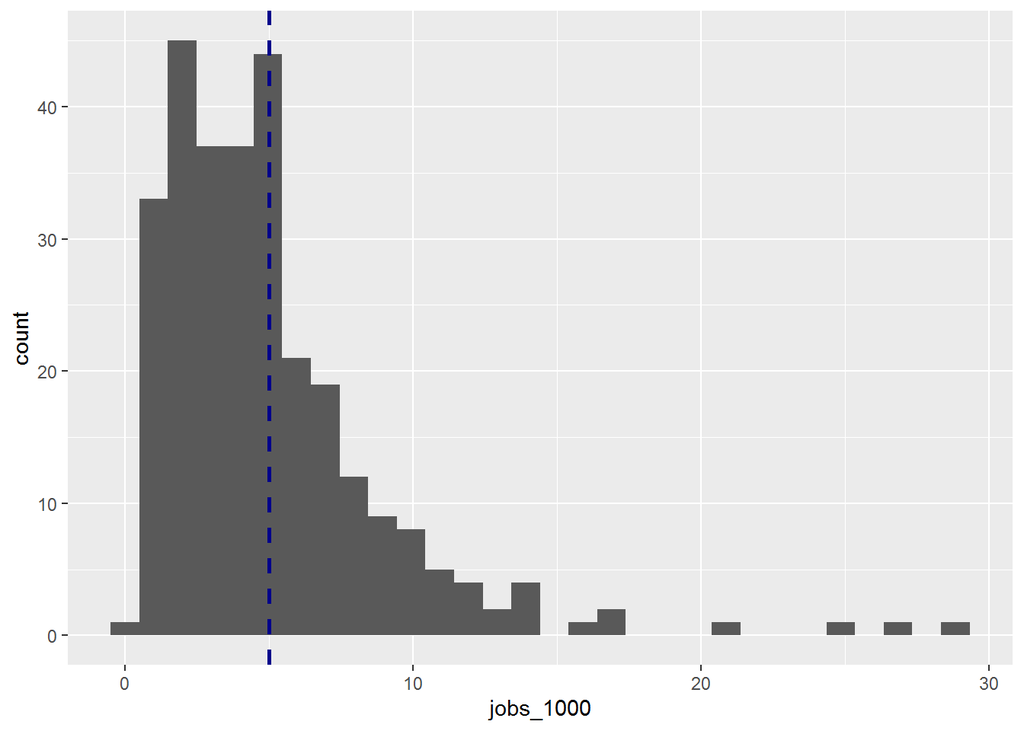

#### Saving to a file

Finally, we’ll save the underlying data in a single Excel file for easy sharing, in case you want to explore the entire list of all states/metros included here.

```r
sheets <- list("states_homehealthaides" = states_homehealthaides,
              "msa_homehealthaides" = msa_homehealthaides,
              "national_homehealthaides" = national_homehealthaides)

write_xlsx(sheets, "output/exported_homehealthaides.xlsx")
```